[figure not shown]

LI-46

Front Fog Light Bulb

LIGHTING SYSTEM

23.Front Fog Light Bulb

A: REMOVAL

1) Disconnect the ground cable from battery. <Ref. to NT-5, BATTERY, NOTE, Note.>

NOTE:

For models other than STI model, disconnect the ground terminal from battery sensor.

2) Remove the clips, and turn over the mud guard - front.

3) Disconnect the connector and remove the front fog light bulb. <Ref. to LI-42, DISASSEMBLY, Front Fog

Light Assembly.>

LI-01724

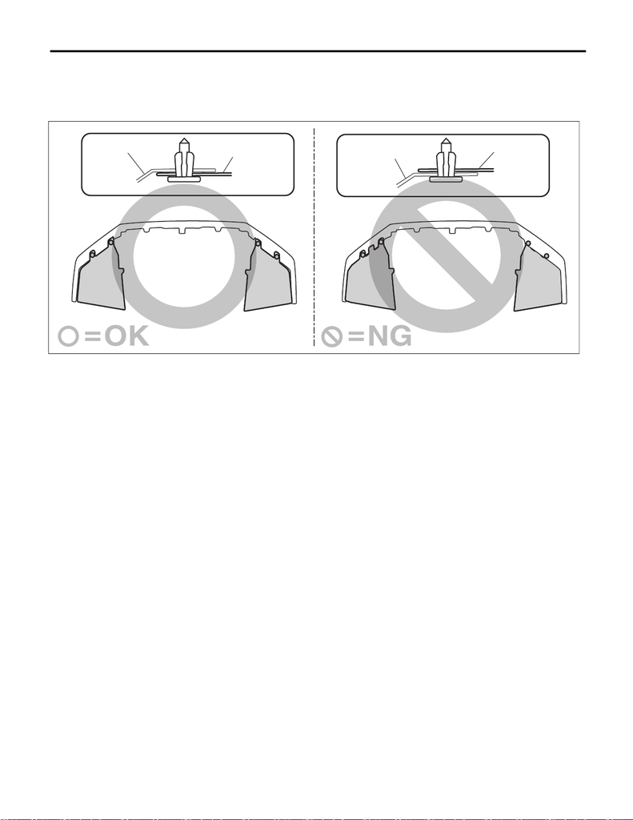

LI-47

Front Fog Light Bulb

LIGHTING SYSTEM

B: INSTALLATION

CAUTION:

Install the mud guard - front so that the front end of the mud guard (b) comes outside the bumper face -

front (a).

CAUTION:

After connecting the connector, make sure that the bulb is locked securely.

1) Install the front fog light bulb. <Ref. to LI-42, ASSEMBLY, Front Fog Light Assembly.>

2) Install the mud guard - front.

3) Connect the battery ground terminal. <Ref. to NT-5, BATTERY, NOTE, Note.>

NOTE:

For models other than STI model, connect the ground terminal to battery sensor.

COM00136

(a)

(b)

(a)

(b)